# Mitochondrial mutational spectrum of birds is associated with increased metabolism

Yury Gusarov

2022-07-07

## Background

Fish and mammals articles: Ah to Gh and Ch to Th mutations are signatures of increased metabolism.  
Hypothesis: Do birds followthose rules?

#### 1.Preparing a birds genetic + ecology dataset

##### 1.1 Read birds mtDNA data and remove extra columns

```r
df_mtdna = read.csv('../../Body/3Results/Birds_mtDNA_data.csv')
df_mtdna$trophic_level = NA
df_mtdna$trophic_niche = NA
df_mtdna$foraging_niche = NA
df_mtdna = df_mtdna[, colSums(is.na(df_mtdna)) < nrow(df_mtdna)]
```

##### 1.2. Calculate mtDNA describing metrics

```r
df_mtdna$ghahSkew = (df_mtdna$neutral_c - df_mtdna$neutral_T)/(df_mtdna$neutral_c + df_mtdna$neutral_T)
df_mtdna$fAn = df_mtdna$neutral_A/df_mtdna$neutral_amount
df_mtdna$fGn = df_mtdna$neutral_g/df_mtdna$neutral_amount
df_mtdna$fCn = df_mtdna$neutral_c/df_mtdna$neutral_amount
df_mtdna$fTn = df_mtdna$neutral_T/df_mtdna$neutral_amount
df_mtdna$Stg = df_mtdna$fAn + df_mtdna$fCn
df_mtdna$Sac = df_mtdna$fTn + df_mtdna$fGn
df_mtdna$Stg_Sac = df_mtdna$Stg - df_mtdna$Sac
```

##### 1.3 Codon normalisation

```r
df_norm = df_mtdna[df_mtdna$gene_name != 'ND6',] #deleting ND6
vec_all = c('TTC','TTT','TCC','TCT','TAC','TAT','TGC','TGT',
            'TTA','TTG','TCA','TCG','TAA','TAG','TGA','TGG',
            'CTC','CTT','CCC','CCT','CAC','CAT','CGC','CGT',
            'CTA','CTG','CCA','CCG','CAA','CAG','CGA','CGG',
            'ATC','ATT','ACC','ACT','AAC','AAT','AGC','AGT',
            'ATA','ATG','ACA','ACG','AAA','AAG','AGA','AGG',
            'GTC','GTT','GCC','GCT','GAC','GAT','GGC','GGT',
            'GTA','GTG','GCA','GCG','GAA','GAG','GGA','GGG')

needed_codons = c('TTC','TCC','TAC','TGC',
                  'TTA','TCA','TAA','TGA',
                  'CTC','CCC','CAC','CGC',
                  'CTA','CCA','CAA','CGA',
                  'ATC','ACC','AAC','AGC',
                  'ATA','ACA','AAA','AGA',
                  'GTC','GCC','GAC','GGC',
                  'GTA','GCA','GAA','GGA')
dfn = c(names(df_norm))
sp_sum_gen = data.frame(unique(df_norm$species_name))

for ( codon in vec_all){

  sum_of_codon = aggregate(df_norm[ ,codon], by = list(df_norm$species_name), FUN = 'sum')[2]
  sp_sum_gen = cbind(sp_sum_gen, sum_of_codon)

}
names(sp_sum_gen) = c('Species', vec_all)

codon_norm = data.frame()

for (i in 1:nrow(sp_sum_gen)){
  org_gen = sp_sum_gen[i,]
  org_gen = as.vector(org_gen)
  df_out= data.frame(sp_sum_gen[i,]$Species)
  for (codon in seq(from = 2, to = 65, by = 2)){
    if (org_gen[1,codon] == 0) {df_out = cbind(df_out, 0)}
    else {
      norm_cod = org_gen[1,codon] / (org_gen[1,codon+1] + org_gen[1,codon])
      df_out = cbind(df_out, norm_cod)
    }
  }
  names(df_out) = c('Species', needed_codons)
  codon_norm = rbind(codon_norm,df_out)
}
names(codon_norm) = c('species_name', needed_codons)
codon_norm = codon_norm %>% select(-c('TAA','AGA'))



final = data.frame()
for (org in 1:nrow(codon_norm)){
  sp_r = codon_norm[org,]

  vec_of_c = sp_r %>% select(TTC, TCC, TAC, TGC, CTC, CCC, CAC, CGC,
                             ATC, ACC, AAC, AGC, GTC, GCC, GAC, GGC)
  vec_of_a = sp_r %>% select(TTA, TCA, TGA, CTA, CCA, CAA, CGA,
                             ATA, ACA, AAA, GTA, GCA, GAA, GGA)

  med_c = median(as.numeric(vec_of_c), na.rm = TRUE)
  med_a = median(as.numeric(vec_of_a), na.rm = TRUE)
  sp_out = data.frame(sp_r$species_name, med_c, med_a)
  final = rbind(final,sp_out)
}
names(final) = c('species_name', 'med_c', 'med_a')
df_mtdna = merge(df_mtdna, final, by = 'species_name')
df_eco = read.csv('../../Body/1Raw/Avonet_data.csv')
df_eco = df_eco[c(1,9,10,11,12,13,14,15,17,18,19,25,28,29,30)]
names(df_eco) = c('species_name','Beak_length_Culmen', 'Beak_length_Nares', 'Beak_width', 'Beak_depth', 'Tarsus_length', 'Wing_length',
                  'Kipps_distance', 'Hand_wing_index', 'Tail_length', 'Mass', 'Habitat', 'Trophic_level', 'Trophic_niche', 'Primary_lifestyle')
df_mtdna = merge(df_mtdna, df_eco, by = 'species_name')
```

As a result, we got a database of 766 birds species with their genetics and ecology

#### 2. Is there a nucleotide content shift in birds mtDNA?

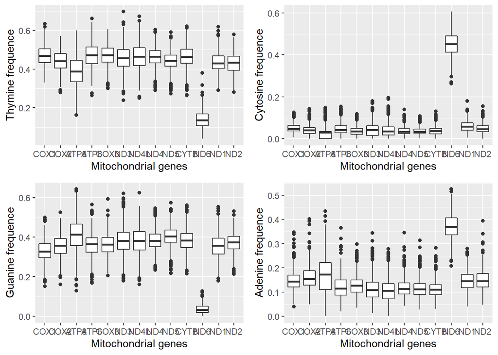

```r
f1 = ggplot(data = df_mtdna, aes(x = gene_name, y = fAn))+
  geom_boxplot()+
  xlab('Mitochondrial genes')+
  ylab('Thymine frequence')
f1 = f1 +xlim(c("COX1","COX2","ATP8","ATP6","COX3", "ND3", "ND4L","ND4","ND5","CYTB","ND6","ND1","ND2"))
f2 = ggplot(data = df_mtdna, aes(x = gene_name, y = fGn))+
  geom_boxplot()+
  xlab('Mitochondrial genes')+
  ylab('Cytosine frequence')
f2 = f2 +xlim(c("COX1","COX2","ATP8","ATP6","COX3", "ND3", "ND4L","ND4","ND5","CYTB","ND6","ND1","ND2"))
f3 = ggplot(data = df_mtdna, aes(x = gene_name, y = fCn))+
  geom_boxplot()+
  xlab('Mitochondrial genes')+
  ylab('Guanine frequence')
f3 = f3 +xlim(c("COX1","COX2","ATP8","ATP6","COX3", "ND3", "ND4L","ND4","ND5","CYTB","ND6","ND1","ND2"))
f4 = ggplot(data = df_mtdna, aes(x = gene_name, y = fTn))+
  geom_boxplot()+
  xlab('Mitochondrial genes')+
  ylab('Adenine frequence')
f4 = f4 +xlim(c("COX1","COX2","ATP8","ATP6","COX3", "ND3", "ND4L","ND4","ND5","CYTB","ND6","ND1","ND2"))
f5 = ggarrange(f1, f2, f3, f4,
                ncol = 2, nrow = 2)
f5
```

According to our boxplots, we can see that frequencies of G and T are higher then A and C

#### 3. What drives those nucleotide shifts?

##### 3.1 Trophic level

To evaluate the influence of ROS on birds mtDNA, we looked at combination of ecology and genetics First we decided to look at birds trophic level ***

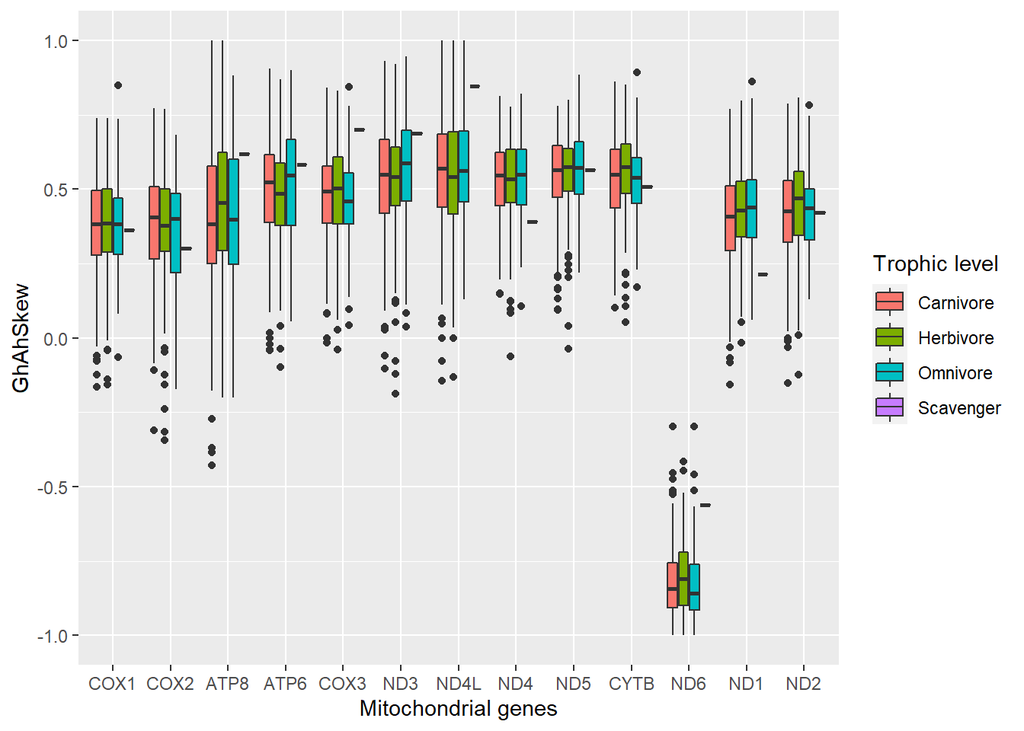

```r
g1 = ggplot(data = df_mtdna, aes(x = gene_name, y = ghahSkew))+
  geom_boxplot(aes(fill = Trophic_level))+
  xlab('Mitochondrial genes')+
  ylab('GhAhSkew')+
  guides(fill = guide_legend(title = "Trophic level"))
g1 = g1 + xlim(c("COX1","COX2","ATP8","ATP6","COX3", "ND3", "ND4L","ND4","ND5","CYTB","ND6","ND1","ND2"))
g1
```

***

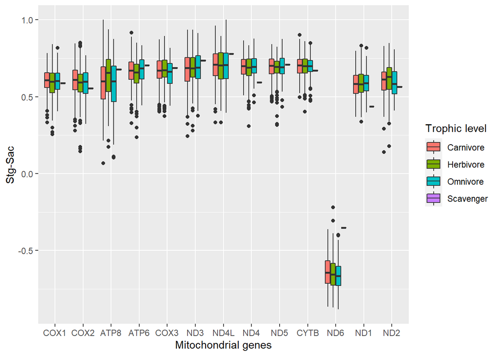

```r
g2 = ggplot(data = df_mtdna, aes(x = gene_name, y = Stg_Sac))+
  geom_boxplot(aes(fill = Trophic_level))+
  xlab('Mitochondrial genes')+
  ylab('Stg-Sac')+
  guides(fill = guide_legend(title = "Trophic level"))
g2 = g2 + xlim(c("COX1","COX2","ATP8","ATP6","COX3", "ND3", "ND4L","ND4","ND5","CYTB","ND6","ND1","ND2"))
g2
```

***

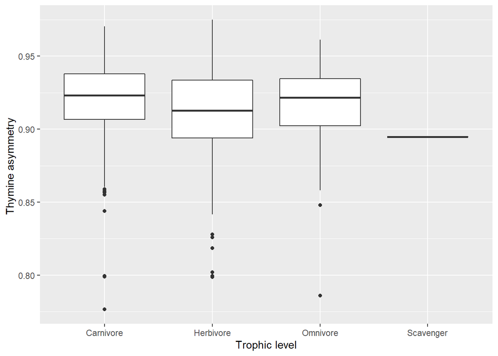

```r
g3 = ggplot(data = df_mtdna, aes(x = Trophic_level, y = med_a))+
  geom_boxplot()+
  xlab('Trophic level')+
  ylab('Thymine asymmetry ')+
  guides(fill = guide_legend(title = "Trophic level"))
g3
```

***

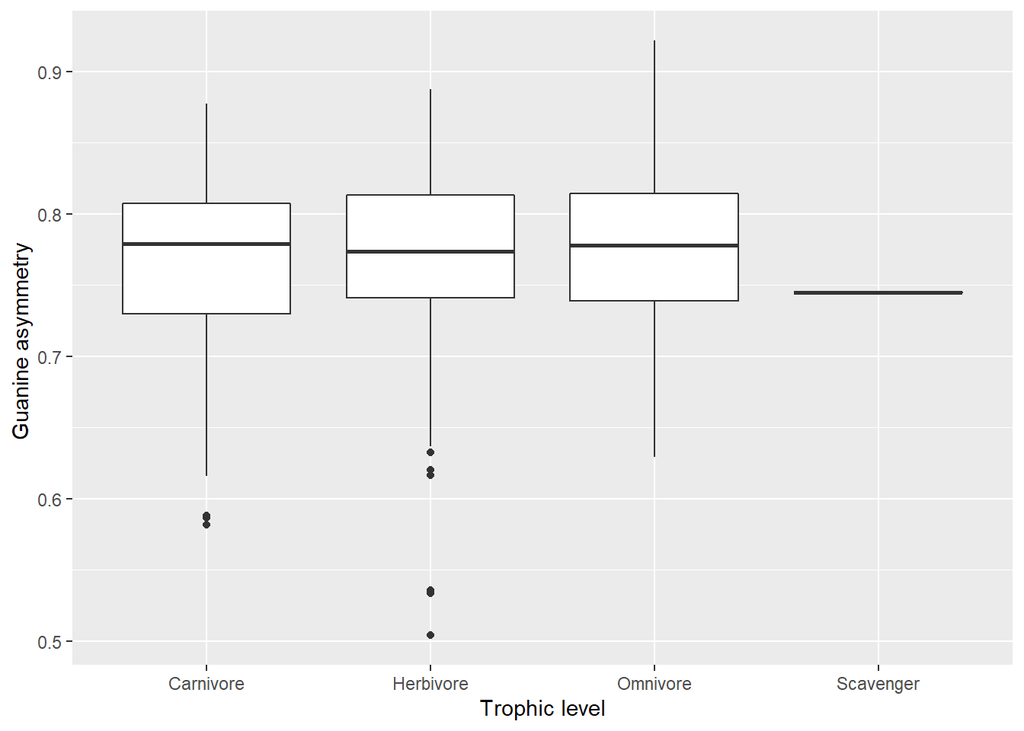

```r
g4 = ggplot(data = df_mtdna, aes(x = Trophic_level, y = med_c))+
  geom_boxplot()+
  xlab('Trophic level')+
  ylab('Guanine asymmetry ')+
  guides(fill = guide_legend(title = "Trophic level"))
g4
```

According to our boxplots, we can see that carnivore and omnivore birds have more guanine and thymine in their mtDNA

##### 3.2 Realm

Next we decided to look at birds realms or ecozones ***

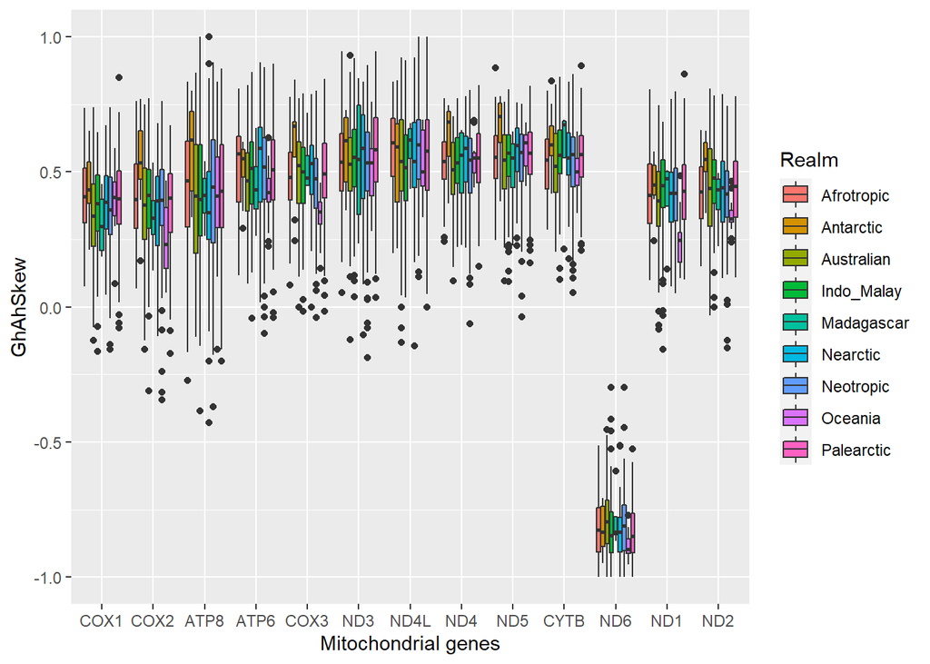

```r
h1 = ggplot(data = df_mtdna, aes(x = gene_name, y = ghahSkew))+
  geom_boxplot(aes(fill = realm))+
  xlab('Mitochondrial genes')+
  ylab('GhAhSkew')+
  guides(fill = guide_legend(title = "Realm"))
h1 = h1 + xlim(c("COX1","COX2","ATP8","ATP6","COX3", "ND3", "ND4L","ND4","ND5","CYTB","ND6","ND1","ND2"))
h1
```

***

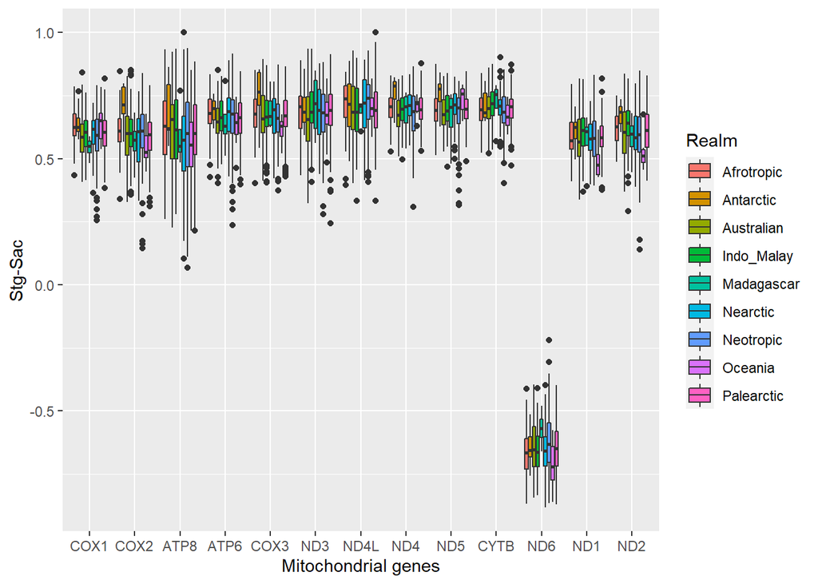

```r
h2 = ggplot(data = df_mtdna, aes(x = gene_name, y = Stg_Sac))+
  geom_boxplot(aes(fill = realm))+
  xlab('Mitochondrial genes')+
  ylab('Stg-Sac')+
  guides(fill = guide_legend(title = "Realm"))
h2 = h2 + xlim(c("COX1","COX2","ATP8","ATP6","COX3", "ND3", "ND4L","ND4","ND5","CYTB","ND6","ND1","ND2"))
h2
```

***

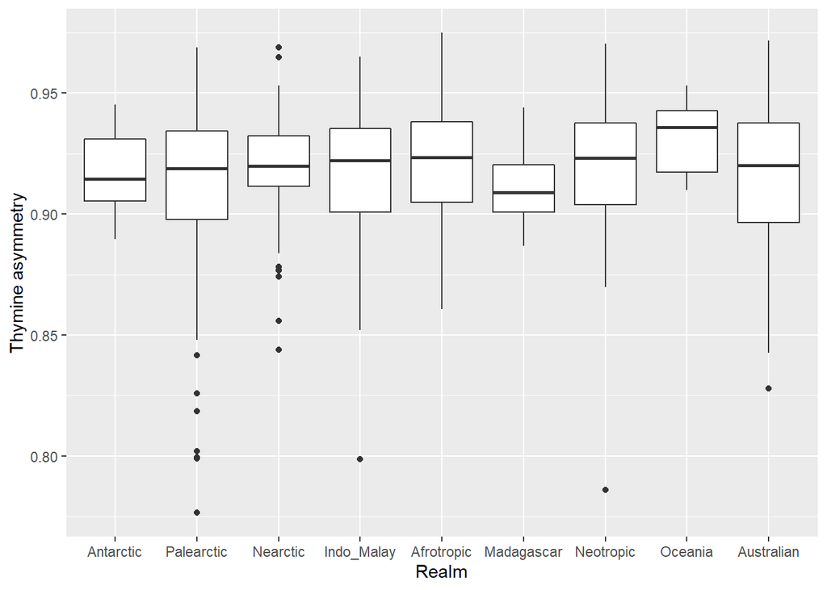

```r
h3 = ggplot(data = df_mtdna, aes(x = realm, y = med_a))+
  geom_boxplot()+
  xlab('Realm')+
  ylab('Thymine asymmetry')+
  guides(fill = guide_legend(title = "Realm"))
h3 = h3 + xlim(c('Antarctic', 'Palearctic', 'Nearctic', 'Indo_Malay', 'Afrotropic', 'Madagascar', 'Neotropic', 'Oceania', 'Australian' ))
h3
```

***

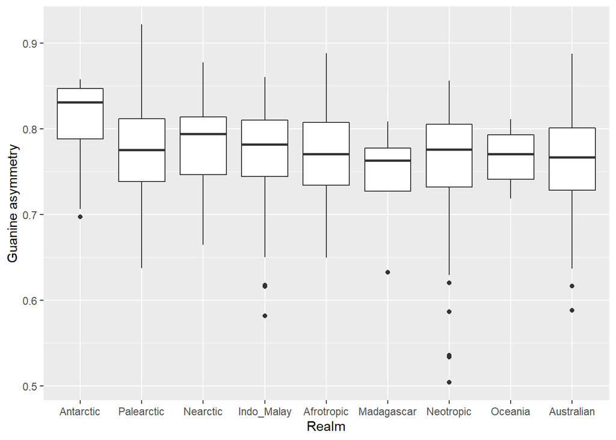

```r
h4 = ggplot(data = df_mtdna, aes(x = realm, y = med_c))+
  geom_boxplot()+
  xlab('Realm')+
  ylab('Guanine asymmetry')+
  guides(fill = guide_legend(title = "Realm"))
h4 = h4 + xlim(c('Antarctic', 'Palearctic', 'Nearctic', 'Indo_Malay', 'Afrotropic', 'Madagascar', 'Neotropic', 'Oceania', 'Australian' ))
h4
```

#### 4. PCA analysis

To see, that increase of G and T is driven by mutagenesis, not natural selection, we made a PCA analysis to check this theory  
***

```r
df_pca = df_mtdna[c('species_name','gene_name','fAn', 'fGn', 'fCn', 'fTn', 'Stg_Sac','ghahSkew', 'med_a', 'med_c')]
df_pca = df_pca[df_pca$gene_name != 'ND6',]
gene_vector = c('fAn', 'fGn', 'fCn', 'fTn', 'Stg_Sac','ghahSkew', 'med_a', 'med_c')
gene_stats = data.frame(unique(df_pca$species_name))
eco = df_mtdna[c('species_name','realm', 'Trophic_level')]
for ( char in gene_vector){

  stats1 = aggregate(df_pca[,char], by = list(df_pca$species_name), FUN = 'sum')[2]
  stats1 = stats1/12
  gene_stats = cbind(gene_stats, stats1)

}
names(gene_stats) = c('species_name', gene_vector)
gene_stats = merge(gene_stats, eco, by = 'species_name')
gene_stats = unique(gene_stats)
row.names(gene_stats) = gene_stats$species_name
gene_stats$species_name = NA
gene_stats = gene_stats[, colSums(is.na(gene_stats)) < nrow(gene_stats)]
stats_pca = prcomp(gene_stats[c(1,2,3,4,5,6,7,8)], center = TRUE, scale. = TRUE)
summary(stats_pca)
```

```
## Importance of components:
##                           PC1    PC2    PC3     PC4     PC5     PC6       PC7
## Standard deviation     2.0521 1.4616 1.1513 0.48254 0.29455 0.08751 1.352e-15
## Proportion of Variance 0.5264 0.2670 0.1657 0.02911 0.01084 0.00096 0.000e+00
## Cumulative Proportion  0.5264 0.7934 0.9591 0.98820 0.99904 1.00000 1.000e+00
##                              PC8
## Standard deviation     9.315e-16
## Proportion of Variance 0.000e+00
## Cumulative Proportion  1.000e+00
```

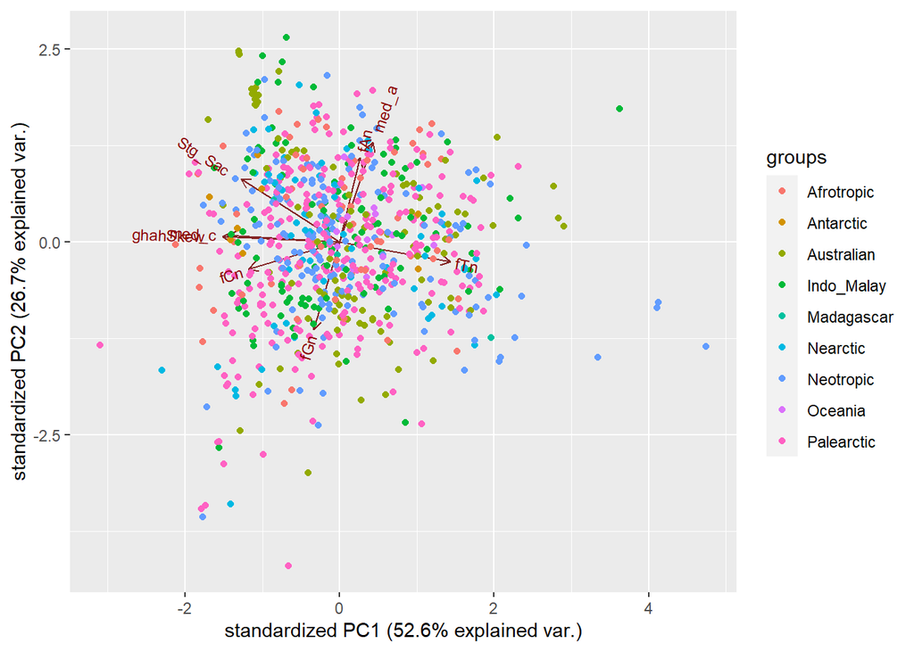

```r
bipl = ggbiplot(stats_pca, groups = gene_stats$realm)
bipl
```

#### 5. PGLS analysis

```r
tree = read.tree("../../Body/3Results/phylo.treefile")
phy=multi2di(tree)
```

[output not shown]